## Description

This system recommends movies to customers. Two recommendation approaches implemented are:  
User based collaborative filtering (UBCF) and Item based collaborative filtering (IBCF).

These approaches are evaluated and compared using different algorithms, normalization techiques, similarity methods and neighborhood sizes. The recommenderlab library is used to accomplish this task.

## DataSet

The dataset from https://grouplens.org/datasets/movielens/ listed under *Recommended for Education and Research* is downloaded. This dataset contains 100,000 ratings for 9,000 movies by 700 users. The ratings are on the scale of 0-5.

Load the downloaded data from csv files.

```r
set.seed(3445) # to keep #s from the results the same

# Set the working directory
setwd("/Users/tulasiramarao/Documents/Tulasi/CUNYProjects/DATA643/RPrograms")

# load data from local drive
dfmovies <- read.csv("MovieRatingsData/ml-latest-small/movies.csv", header = TRUE, sep = ",",
                   stringsAsFactors = FALSE, encoding = "UTF-8")
dfratings <- read.csv("MovieRatingsData/ml-latest-small/ratings.csv", header = TRUE, sep =",",
                    stringsAsFactors = FALSE)

colnames(dfratings)
```

```
## [1] "userId"    "movieId"   "rating"    "timestamp"
```

Select the relevant columns by using numbers to generalize the subset method for other datasets.

```r
colnames(dfratings)
```

```
## [1] "userId"    "movieId"   "rating"    "timestamp"
```

```r
myratings <- subset(dfratings,select = c(1,2,3))
#colnames(myratings)
```

Using dplyr to reformat - making rating to be the values in the matrix; user as rows, movies as columns. Also converting the dataframe to matrix to feed to the recommenderlab library.

```r
reformatted.df <- myratings %>%
  spread(key = movieId, value = rating) %>%
  as.matrix()

# Remove first column - userid ( rows are users so no need for userid)
mydf = reformatted.df[,-1]  # Note: Not using subset to make this a generalized code
```

```r
mydf <- as(mydf, "realRatingMatrix")

# look at dimension & size
#171 9066
# 1.7 MB
dim(mydf)
```

```
## [1]  671 9066
```

```r
# Originally it was 46.0 MB
#171 9066
dim(reformatted.df)
```

```
## [1]  671 9067
```

The following image displays the heatmap of the rating matrix. The white area in the top right region is because the row and the column are sorted.

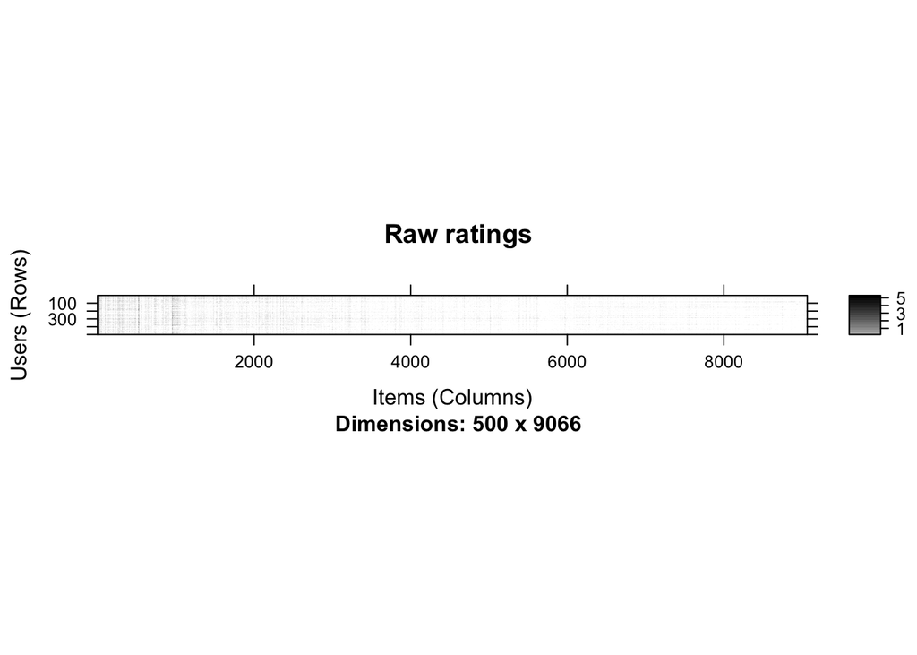

```r
image(sample(mydf,500),main="Raw ratings")
```

and the following image displays the histogram of the ratings of scale 0-5

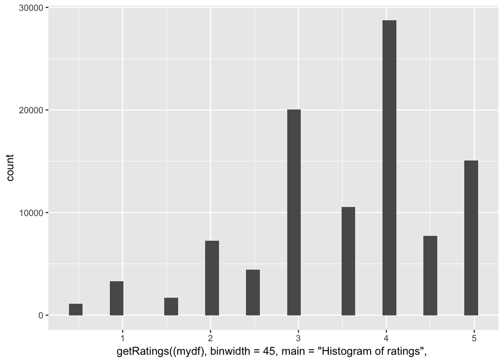

```r
qplot(getRatings((mydf),binwidth = 45, main ="Histogram of ratings", xlab = "Rating"))
```

```r
summary(getRatings(mydf)) # skewed to the right
```

```
##    Min. 1st Qu.  Median    Mean 3rd Qu.    Max.
##   0.500   3.000   4.000   3.544   4.000   5.000
```

## Data preparation:

Data is prepared based on instructions under Chapter 3 of “Building a recommendation system with R” - from Suresh Gorakala)

The movies dataset contains movies that have been viewed only a few times with ratings biased because of the lack of datapoints. Also the users rated a few movies making the ratings biased also. So its necessary to have a required minimum of users and movies. So we will define ratings_movies containing the matrix - with uesers that have rated at least x movies and movies that have been watched at least y times.

```r
# Movies viewed > 10 times
ratings_movies <- mydf[,colCounts(mydf) > 10]

# Creates a 671 x 2083 rating matrix of class ‘realRatingMatrix’ with 80295 ratings.
ratings_movies
```

```
## 671 x 2083 rating matrix of class 'realRatingMatrix' with 80295 ratings.
```

Chapter 4 uses the evaluationScheme to automatically split dataset into Testing and Training sets. So, using this tool to split ratings_movies into 80% and 20%.

```r
items_to_keep <- 5
percentage_training <- 0.8
rating_threshold <- 3
n_eval <- 1

eval_sets <- evaluationScheme(data = ratings_movies, method ="split", train = percentage_training, given = items_to_keep, goodRating = rating_threshold) #, k = n_eval)
#eval_sets

size_sets <- sapply(eval_sets@runsTrain, length)
size_sets
```

```
## [1] 536
```

## Splitting data

To make prediction of ratings, we need to build a recommender. The following sets were extracted by using getData:

Train: The training set  
Known: Test set with the item to build the recommendation  
Unknown: Test set to test the recommendation

```r
getData(eval_sets, "train")
```

```
## 536 x 2083 rating matrix of class 'realRatingMatrix' with 62259 ratings.
```

Its a realRatingMatrix object, and so nrows and ncolumns can be applied to it.

```r
nrow(getData(eval_sets,"train"))/nrow(ratings_movies)
```

```
## [1] 0.7988077
```

80% of data is in the training set as expected.

```r
getData(eval_sets, "known")
```

```
## 135 x 2083 rating matrix of class 'realRatingMatrix' with 675 ratings.
```

```r
getData(eval_sets, "unknown")
```

```
## 135 x 2083 rating matrix of class 'realRatingMatrix' with 17361 ratings.
```

```r
nrow(getData(eval_sets,"known"))/nrow(ratings_movies)
```

```
## [1] 0.2011923
```

They have about the rest of 20% data in the test set.

```r
unique(rowCounts(getData(eval_sets,"known")))
```

```
## [1] 5
```

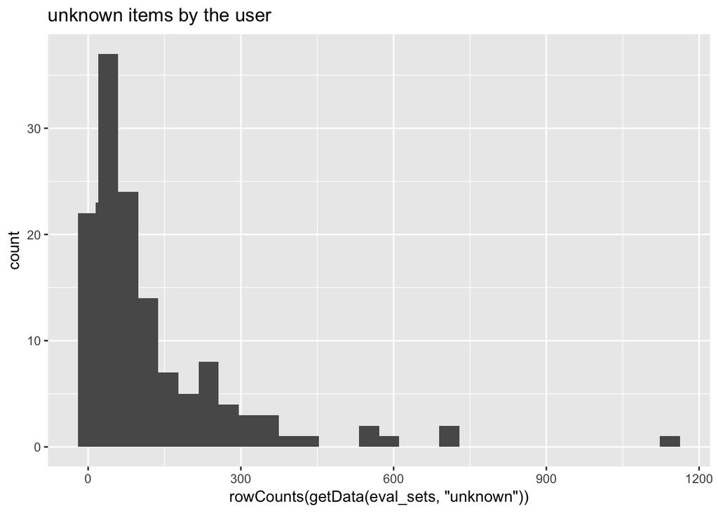

```r
qplot(rowCounts(getData(eval_sets,"unknown")))  +geom_histogram(binwidth = 10) + ggtitle("unknown items by the user")
```

The numbers of movies per user varies a lot as expected.

## Recommendation Algorithms:

Two recommendation algorithms considered are:  
Used based as well as the Item based colloborative filtering.

#### I. User-Based Colloborative Filtering:

This algorithm groups users according to their history of ratings and recommends an item that a user similar to this user (in the same group) liked. So, if user A liked Movie 1,2 and 3 and user B liked Movie 1 and 2, then Movie 3 is a good one to recommend to user B.The assumption of UBCF is that similar users will rate movies similarly. So, the ratings are predicted by first finding a neighborhood of similar users and then aggregating the user ratings to form a prediction.

Popular measures used are Pearson and cosine distance similarity.

```r
#Description of UBCF
recommenderRegistry$get_entry('UBCF', dataType='realRatingMatrix')
```

```
## Recommender method: UBCF for realRatingMatrix
## Description: Recommender based on user-based collaborative filtering.
## Reference: NA
## Parameters:
##     method nn sample normalize
## 1 "cosine" 25  FALSE  "center"
```

#### a) Optimizing a numeric parameter ( Neighborhood size):

```r
vector_k <- c(10, 20, 30,40,50,60,70)
records <- c(5, 10, 15, 20, 25)
model_name <- "UBCF"
method_name <- "Cosine"

#define a list of models to evaluate by using lapply( distance metric is cosine )
models_to_evaluate <- lapply(vector_k, function(k) {
  list(name= model_name, param = list(normalize = "Z-score", method = method_name,nn=k))

})

names(models_to_evaluate) <- paste0(("UBCF_k_"),vector_k)
list_results <- evaluate(x=eval_sets,method = models_to_evaluate, n = vector_k,progress = FALSE)
```

```
## UBCF run fold/sample [model time/prediction time]
##   1  [0.027sec/1.228sec]
## UBCF run fold/sample [model time/prediction time]
##   1  [0.021sec/1.365sec]
## UBCF run fold/sample [model time/prediction time]
##   1  [0.026sec/1.317sec]
## UBCF run fold/sample [model time/prediction time]
##   1  [0.026sec/1.177sec]
## UBCF run fold/sample [model time/prediction time]
##   1  [0.023sec/1.34sec]
## UBCF run fold/sample [model time/prediction time]
##   1  [0.021sec/1.173sec]
## UBCF run fold/sample [model time/prediction time]
##   1  [0.021sec/1.173sec]
```

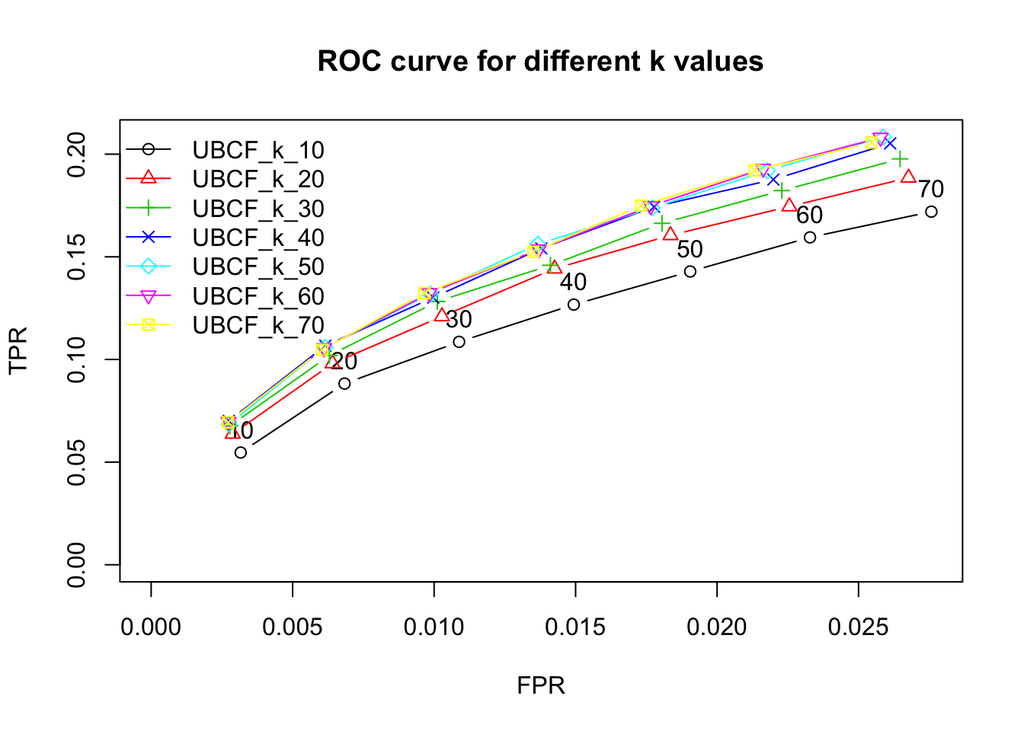

```r
plot(list_results, annotate = 1, legend ="topleft")
title("ROC curve for different k values")
```

The best performing can be identified by building a chart for these values with the ROC curve. ROC curve has the best performance for K = 70. So this value will be used in the neighborhood is ideal for all calculations.

Now a similarity matrix is calculated containing all user-to-user similarities using Pearson and Cosine similary measures.

```r
model_to_evaluate <- "UBCF"
model_parameters <- list(normalize = "Z-Score", method="Cosine", nn=70)

model_cosine <- Recommender(getData(eval_sets,"train"),model_to_evaluate,param=model_parameters)

prediction_cosine <- predict(model_cosine,getData(eval_sets,"known"),type="ratings")

rmse_cosine <- calcPredictionAccuracy(prediction_cosine, getData(eval_sets, "unknown"))[1]
rmse_cosine
```

```
##     RMSE
## 1.068368
```

#### b. Distance methods:

This method gives measurement of the similarity between users/items based on the distance between them.Popular models are pearson, jaccard and cosine.

```r
model_to_evaluate <- "UBCF"
kval <- 50
valList <- c(1, 5, 10, 15, 20, 25)

model_parameters1 <- list(normalize = "Z-score",method="Cosine",nn=kval)
model_parameters2 <- list(normalize = "Z-score",method="Pearson",nn=kval)
model_parameters3 <- list(normalize = "Z-score",method="jaccard",nn=kval)


distItem <- list(
   "Cosine" = list(name=model_to_evaluate, param=model_parameters1),
   "Pearson" = list(name=model_to_evaluate, param=model_parameters2),
   "Jaccard" = list(name=model_to_evaluate, param=model_parameters3)

)

dist_resultsUBCF <- evaluate(eval_sets, distItem, n=valList)
```

```
## UBCF run fold/sample [model time/prediction time]
##   1  [0.03sec/1.184sec]
## UBCF run fold/sample [model time/prediction time]
##   1  [0.048sec/0.66sec]
## UBCF run fold/sample [model time/prediction time]
##   1  [0.02sec/0.752sec]
```

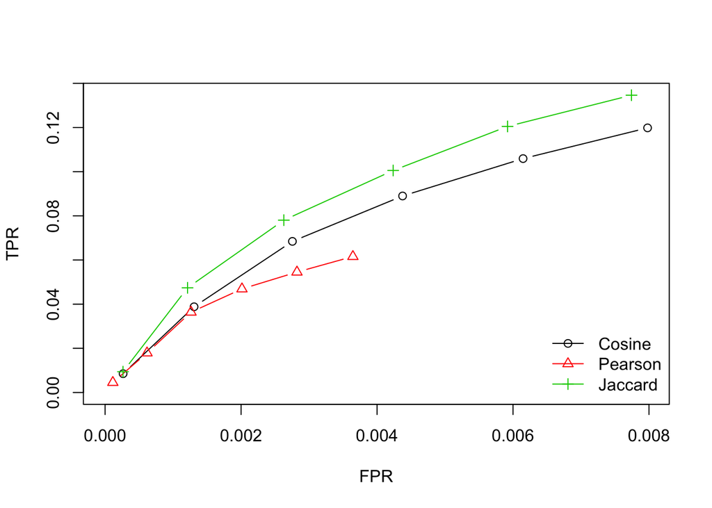

```r
plot(x=dist_resultsUBCF, y ="ROC")
```

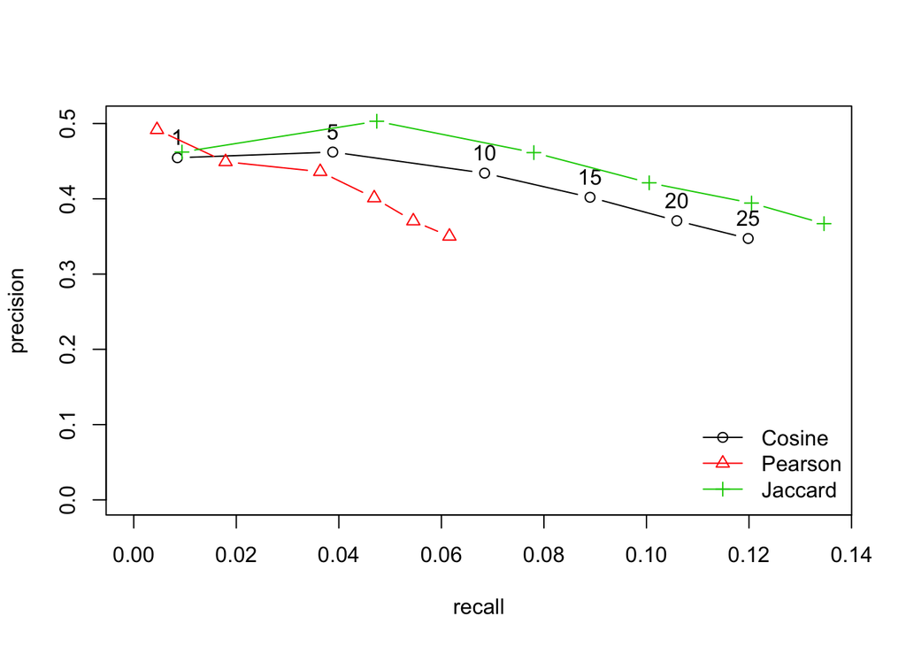

```r
# Draw the precision/Recall curve
plot(x = dist_resultsUBCF, y = "prec/rec", annotate = 1)
```

Jaccard performed best in the Precision/Recall curve as it can be seen at the top of the screen.

So calculate the RMSE for both Jaccard and Pearson to compare and choose the best one.

```r
# Calculate RMSE for both Jaccard and Pearson

# First Pearson
# use k=70 as determined from the ROC curve above for choosing the neighborhood
model_to_evaluate <- "UBCF"
model_parameters <- list(normalize = "Z-Score", method="Pearson", nn=70)

model_pear <- Recommender(getData(eval_sets,"train"),model_to_evaluate,param=model_parameters)

prediction_pear <- predict(model_pear,getData(eval_sets,"known"),type="ratings")

rmse_pear <- calcPredictionAccuracy(prediction_pear, getData(eval_sets, "unknown"))[1]
rmse_pear
```

```
##      RMSE
## 0.9649986
```

```r
#0.9383786


# Next Jaccard
# use k=70 as determined from the ROC curve above for choosing the neighborhood
model_to_evaluate <- "UBCF"
model_parameters <- list(normalize = "Z-Score", method="jaccard", nn=70)

model_jac <- Recommender(getData(eval_sets,"train"),model_to_evaluate,param=model_parameters)

prediction_jac <- predict(model_jac,getData(eval_sets,"known"),type="ratings")

rmse_jac <- calcPredictionAccuracy(prediction_jac, getData(eval_sets, "unknown"))[1]
rmse_jac
```

```
##     RMSE
## 1.071175
```

```r
#0.974639
```

Pearson RMSE is lower and hence is better than Pearson.

#### c) Normalization method:

Data needs to be normalized before applying any algorithm. (normalization is done here by taking user’s averages - which is mean ratings of every user subtracted from known ratings)

Use normalization method for Z score using center and z-score parameters to feed the recommenderlab.

```r
alg_dist <- list(
   "center" = list(name="UBCF", param=list(normalize = "center",method="Cosine",nn=70)),
   "Zscore" = list(name="UBCF", param=list(normalize = "Z-score",method="Cosine",nn=70))
)

dist_resultsUBCF <- evaluate(eval_sets, alg_dist, n=c(1, 5, 10, 15, 20, 25))
```

```
## UBCF run fold/sample [model time/prediction time]
##   1  [0.006sec/1.202sec]
## UBCF run fold/sample [model time/prediction time]
##   1  [0.025sec/1.228sec]
```

Now plot the ROC and the precision curve to compare and choose the best between center and z-score methods.

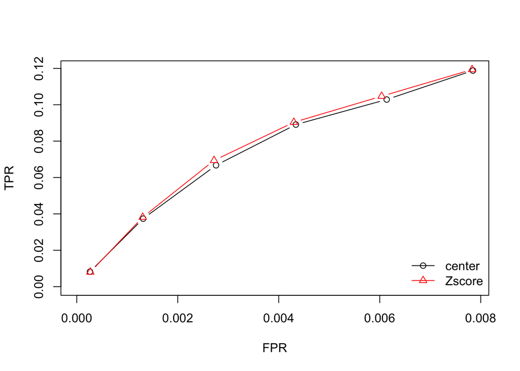

```r
#plot ROC
plot(x = dist_resultsUBCF, y = "ROC")
```

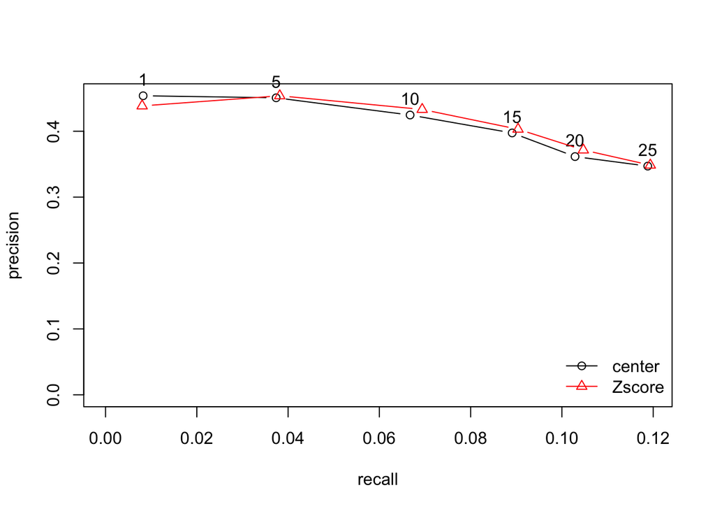

```r
# Draw the precision curve
plot(x = dist_resultsUBCF, y = "prec", annotate = 1)
```

## II. Item-Based Collaborative-Filtering Recommender(IBCF):

This is a model based recommender based on the relationship between items inferred from the rating matrix. This model assumes that users prefer movies/items that are similar to other items they like.

```r
#Description of IBCF
recommenderRegistry$get_entry('IBCF', dataType='realRatingMatrix')
```

```
## Recommender method: IBCF for realRatingMatrix
## Description: Recommender based on item-based collaborative filtering.
## Reference: NA
## Parameters:
##    k   method normalize normalize_sim_matrix alpha na_as_zero
## 1 30 "Cosine"  "center"                FALSE   0.5      FALSE
```

#### a) Optimizing a numeric paramter(( Neighborhood size)):

```r
vector_k <- c(10, 20, 30,40,50,60,70)
records <- c(5, 10, 15, 20, 25)
model_name <- "IBCF"
method_name <- "Cosine"

#define a list of models to evaluate by using lapply( distance metric is cosine )
models_to_evaluate <- lapply(vector_k, function(k) {
  list(name= model_name, param = list(normalize = "Z-score", method = method_name,k=k))

})

names(models_to_evaluate) <- paste0(("IBCF_k_"),vector_k)
list_results <- evaluate(x=eval_sets,method = models_to_evaluate, n = vector_k,progress = FALSE)
```

```
## IBCF run fold/sample [model time/prediction time]
##   1  [43.728sec/0.079sec]
## IBCF run fold/sample [model time/prediction time]
##   1  [42.682sec/0.059sec]
## IBCF run fold/sample [model time/prediction time]
##   1  [42.521sec/0.062sec]
## IBCF run fold/sample [model time/prediction time]
##   1  [43.372sec/0.06sec]
## IBCF run fold/sample [model time/prediction time]
##   1  [46.317sec/0.074sec]
## IBCF run fold/sample [model time/prediction time]
##   1  [44.961sec/0.072sec]
## IBCF run fold/sample [model time/prediction time]
##   1  [43.449sec/0.087sec]
```

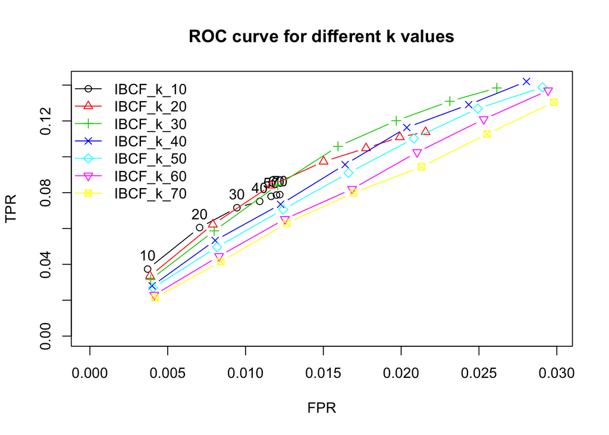

```r
plot(list_results, annotate = 1, legend ="topleft")
title("ROC curve for different k values")
```

This evaluation took a long time to run about 50 seconds for each iteration.  
It can be seen from the ROC curves that the best performance is for k=30. So including 30 items in the neighborhood is ideal for all calculations.

```r
# k =30 determined from the ROC curve above for choosing the neighborhood
model_to_evaluate <- "UBCF"
model_parameters <- list(normalize = "Z-Score", method="Cosine", nn=30)

model_cosine <- Recommender(getData(eval_sets,"train"),model_to_evaluate,param=model_parameters)


prediction_cosine <- predict(model_cosine,getData(eval_sets,"known"),type="ratings")

rmse_cosine <- calcPredictionAccuracy(prediction_cosine, getData(eval_sets, "unknown"))[1]
rmse_cosine
```

```
##     RMSE
## 1.066854
```

#### b) Distance methods:

This method gives measurement of the similarity between users/items based on the distance between them.  
Popular models are pearson and cosine.

```r
model_to_evaluate <- "IBCF"
kval <- 10
valList <- c(1, 5, 10, 15, 20, 25)

model_parameters1 <- list(normalize = "Z-score",method="Cosine",k=30)
model_parameters2 <- list(normalize = "Z-score",method="Pearson",k=30)
model_parameters3 <- list(normalize = "Z-score",method="jaccard",k=30)


distItem <- list(
   "Cosine" = list(name=model_to_evaluate, param=model_parameters1),
   "Pearson" = list(name=model_to_evaluate, param=model_parameters2),
   "Jaccard" = list(name=model_to_evaluate, param=model_parameters3)

)

dist_resultsIBCF <- evaluate(eval_sets, distItem, n=valList)
```

```
## IBCF run fold/sample [model time/prediction time]
##   1  [44.099sec/0.068sec]
## IBCF run fold/sample [model time/prediction time]
##   1  [38.86sec/0.057sec]
## IBCF run fold/sample [model time/prediction time]
##   1  [36.814sec/0.085sec]
```

Plot the ROC and the Precision curves to compare the performances of Cosine, Pearson and Jaccard models.

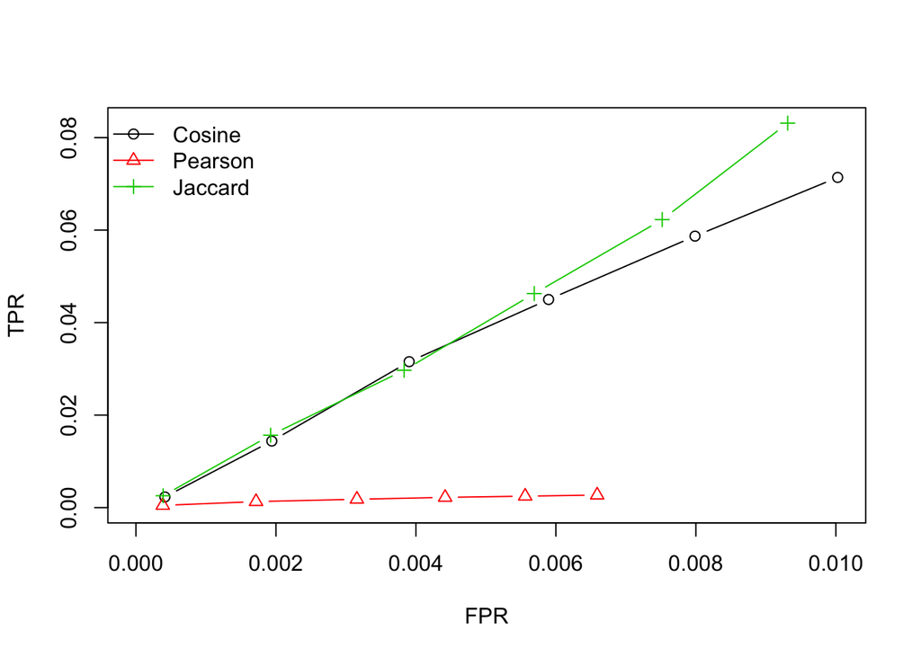

```r
#plot ROC
plot(x = dist_resultsIBCF, y = "ROC",legend ="topleft")
```

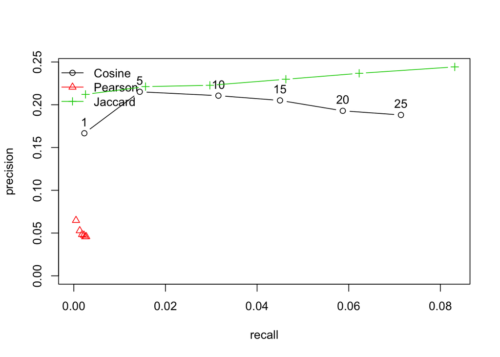

```r
# Draw the precision curve
plot(x = dist_resultsIBCF, y = "prec", annotate = 1,legend ="topleft")
```

Jaccard model performed better again.

```r
# Calculate RMSE

# k = 30 determined from the ROC curve above for choosing the neighborhood
model_to_evaluate <- "IBCF"
model_parameters <- list(normalize = "Z-Score", method="jaccard", k=kval)

model_jac <- Recommender(getData(eval_sets,"train"),model_to_evaluate,param=model_parameters)

prediction_jac <- predict(model_jac,getData(eval_sets,"known"),type="ratings")

rmse_jac <- calcPredictionAccuracy(prediction_jac, getData(eval_sets, "unknown"))[1]
rmse_jac
```

```
##     RMSE
## 1.120729
```